# Looping over columns & rows with tidyverse functions

Add across and rowwise to your looping toolkit

Allison Horst

UCSB Data Analysis & Coding Club (DAnC) 2022-02-24

> “Of course, someone has to write loops. It doesn’t have to be you. — Jenny Bryan”

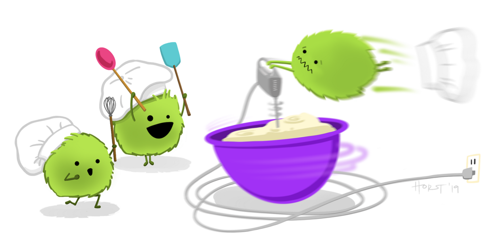

From Hadley Wickham’s 2019 talk on The Joy of Functional Programming (for Data Science)

# Overview

In a previous DAnC workshop, you learned about basic for loops in R to iterate across multiple elements and apply some operation to each. Writing for loops from scratch is a critical skill for any data scientist. But there are also some helpful alternatives! In this session, I’ll:

1. Introduce myself and briefly describe my background in environmental data science (20 - 30 min)
2. Demo several other useful options for iteration with tidyverse functions `dplyr::across()` and `dplyr::rowwise()`

# Set-up

- Create a new R script or R Markdown document OR click the Code > Download button at the top of the shared link to download the pre-populated .Rmd
- Attach the `tidyverse` and `palmerpenguins` packages

```r
library(tidyverse)
library(palmerpenguins)
```

# From scratch for loop refresher

## A reminder loop

When we write a for loop, we ask R to iterate over elements in a series and apply some operation to them. For example, if we had a vector containing “pika”, “fox”, and “octopus” we could automate a statemnt “My favorite animal is the…” followed by each species by writing something like this:

```r
# Create a vector of animals:
animals <- c("pika", "fox", "octopus")

# Write a loop that iterates over all animals, adding "My favorite animal" before:
for (i in seq_along(animals)) {
  statement <- paste("My favorite animal is the", animals[i])
  print(statement)
}
```

```
## [1] "My favorite animal is the pika"
## [1] "My favorite animal is the fox"
## [1] "My favorite animal is the octopus"
```

As a reminder, `seq_along()` is a nice little function that creates a sequence starting at 1, continuing to the length of the vector. For example, `seq_along(animals)` here creates the sequence 1, 2, 3.

## Some other (maybe more realistic) scenarios

There are all kinds of scenarios in data science where we may want to iterate over elements. For example:

- Iterating over columns to find the mean for each
- Iterating over files in a directory to import each
- Iterating over rows to find the mean of all columns by *row*
- Iterating over data frames to create a scatter plot of each
- And a whole bunch more!

# Other options for loops

## dplyr::across()

### Use `dplyr::across()` to iterate across columns

The `dplyr::across()` function “makes it easy to apply the same transformation to multiple columns,” and plays nicely with a number of helper functions and options for customized iteration over the columns you’re interested in. Generally, the `across()` function will be within `mutate()` or `summarize()`, and follows the basic structure:

```r
across(.cols = (which columns?), .fns = (which functions?))
```

Let’s take a look at the `penguins` data with `dplyr::glimpse`:

```r
glimpse(penguins)
```

```
## Rows: 344
## Columns: 8
## $ species           <fct> Adelie, Adelie, Adelie, Adelie, Adelie, Adelie, Adel…
## $ island            <fct> Torgersen, Torgersen, Torgersen, Torgersen, Torgerse…
## $ bill_length_mm    <dbl> 39.1, 39.5, 40.3, NA, 36.7, 39.3, 38.9, 39.2, 34.1, …
## $ bill_depth_mm     <dbl> 18.7, 17.4, 18.0, NA, 19.3, 20.6, 17.8, 19.6, 18.1, …
## $ flipper_length_mm <int> 181, 186, 195, NA, 193, 190, 181, 195, 193, 190, 186…
## $ body_mass_g       <int> 3750, 3800, 3250, NA, 3450, 3650, 3625, 4675, 3475, …
## $ sex               <fct> male, female, female, NA, female, male, female, male…
## $ year              <int> 2007, 2007, 2007, 2007, 2007, 2007, 2007, 2007, 2007…
```

### Example 1: Apply something across all columns

Convert all columns to class “character.”

```r
penguins_chr <- penguins %>%
  mutate(across(.cols = everything(), as.character))

# Check out the classes:
glimpse(penguins_chr)
```

```
## Rows: 344
## Columns: 8
## $ species           <chr> "Adelie", "Adelie", "Adelie", "Adelie", "Adelie", "A…
## $ island            <chr> "Torgersen", "Torgersen", "Torgersen", "Torgersen", …
## $ bill_length_mm    <chr> "39.1", "39.5", "40.3", NA, "36.7", "39.3", "38.9", …
## $ bill_depth_mm     <chr> "18.7", "17.4", "18", NA, "19.3", "20.6", "17.8", "1…
## $ flipper_length_mm <chr> "181", "186", "195", NA, "193", "190", "181", "195",…
## $ body_mass_g       <chr> "3750", "3800", "3250", NA, "3450", "3650", "3625", …
## $ sex               <chr> "male", "female", "female", NA, "female", "male", "f…
## $ year              <chr> "2007", "2007", "2007", "2007", "2007", "2007", "200…
```

### Example 2: Adding `where()` to specify columns

We can also specify which columns we want to apply the function to, using either a vector of column names (e.g. `c(species, island)`) *or* by using little helper functions within `where()`. For example, to only apply the square root (`sqrt`) function across numeric columns, I could use the following within `mutate()`:

```r
across(.cols = where(is.numeric), .fns = sqrt)
```

**Note:** The `species`, `island` and `sex` columns in `penguins` are stored as factors.

Let’s convert all content in any factor variables to lowercase:

```r
penguins %>%
  mutate(across(.cols = where(is.factor), .fns = tolower))
```

```
## # A tibble: 344 × 8
##    species island    bill_length_mm bill_depth_mm flipper_length_mm body_mass_g
##    <chr>   <chr>              <dbl>         <dbl>             <int>       <int>
##  1 adelie  torgersen           39.1          18.7               181        3750
##  2 adelie  torgersen           39.5          17.4               186        3800
##  3 adelie  torgersen           40.3          18                 195        3250
##  4 adelie  torgersen           NA            NA                  NA          NA
##  5 adelie  torgersen           36.7          19.3               193        3450
##  6 adelie  torgersen           39.3          20.6               190        3650
##  7 adelie  torgersen           38.9          17.8               181        3625
##  8 adelie  torgersen           39.2          19.6               195        4675
##  9 adelie  torgersen           34.1          18.1               193        3475
## 10 adelie  torgersen           42            20.2               190        4250
## # … with 334 more rows, and 2 more variables: sex <chr>, year <int>
```

More often, you won’t see the arguments explicitly called, e.g.:

```r
penguins %>%
  mutate(across(where(is.factor), tolower))
```

```
## # A tibble: 344 × 8
##    species island    bill_length_mm bill_depth_mm flipper_length_mm body_mass_g
##    <chr>   <chr>              <dbl>         <dbl>             <int>       <int>
##  1 adelie  torgersen           39.1          18.7               181        3750
##  2 adelie  torgersen           39.5          17.4               186        3800
##  3 adelie  torgersen           40.3          18                 195        3250
##  4 adelie  torgersen           NA            NA                  NA          NA
##  5 adelie  torgersen           36.7          19.3               193        3450
##  6 adelie  torgersen           39.3          20.6               190        3650
##  7 adelie  torgersen           38.9          17.8               181        3625
##  8 adelie  torgersen           39.2          19.6               195        4675
##  9 adelie  torgersen           34.1          18.1               193        3475
## 10 adelie  torgersen           42            20.2               190        4250
## # … with 334 more rows, and 2 more variables: sex <chr>, year <int>
```

### Example 3: Within `summarize()` to find summary statistics by column

Find the mean of all columns that end with `mm`:

```r
penguins %>%
  summarize(across(ends_with("mm"), mean, na.rm = TRUE))
```

```
## # A tibble: 1 × 3
##   bill_length_mm bill_depth_mm flipper_length_mm
##            <dbl>         <dbl>             <dbl>
## 1           43.9          17.2              201.
```

### Example 4: Within `group_by() %>% summarize()`

Find the mean of all columns that start with `bill` by `species`:

```r
penguins %>%
  group_by(species) %>%
  summarize(across(starts_with("bill"), mean, na.rm = TRUE))
```

```
## # A tibble: 3 × 3
##   species   bill_length_mm bill_depth_mm
##   <fct>              <dbl>         <dbl>
## 1 Adelie              38.8          18.3
## 2 Chinstrap           48.8          18.4
## 3 Gentoo              47.5          15.0
```

## dplyr::rowwise()

### Use `dplyr::rowwise()` to iterate over rows

We used `across()` above to apply a function *across* multiple columns. What if we want to perform an operation on each *row*?

You might think, “Oh, just use mutate and do the operation.” But there are some issues with that - like if I have something like this:

| col_a | col_b |
| --- | --- |
| 1 | 1 |
| 10 | 20 |

What happens if we try to use `mutate()` to find the mean of each *row*?

```r
df %>%
  mutate(mean_val = mean(c(col_a, col_b)))
```

```
## # A tibble: 2 × 3
##   col_a col_b mean_val
##   <dbl> <dbl>    <dbl>
## 1     1     1        8
## 2    10    20        8
```

```r
df %>%
  mutate(sum_val = sum(col_a, col_b))
```

```
## # A tibble: 2 × 3
##   col_a col_b sum_val
##   <dbl> <dbl>   <dbl>
## 1     1     1      32
## 2    10    20      32
```

```r
df %>%
  mutate(sum_val = col_a + col_b)
```

```
## # A tibble: 2 × 3
##   col_a col_b sum_val
##   <dbl> <dbl>   <dbl>
## 1     1     1       2
## 2    10    20      30
```

So how do we specify that we want to loop across each row? Use `rowwise()`!

```r
df %>%
  rowwise() %>%
  mutate(mean_val = mean(c(col_a, col_b)))
```

```
## # A tibble: 2 × 3
## # Rowwise:
##   col_a col_b mean_val
##   <dbl> <dbl>    <dbl>
## 1     1     1        1
## 2    10    20       15
```

### Example 5: `rowwise() %>% mutate()` to add a column with a value calculated across rows

Starting with penguins, let’s create a `rowwise()` data frame, then add a new column that is the sum of all values in columns of class `double`. First, let’s chat about what that might look like.

```r
penguins %>%
  rowwise() %>%
  mutate(sum_bill = sum(across(where(is.double))))
```

```
## # A tibble: 344 × 9
## # Rowwise:
##    species island    bill_length_mm bill_depth_mm flipper_length_mm body_mass_g
##    <fct>   <fct>              <dbl>         <dbl>             <int>       <int>
##  1 Adelie  Torgersen           39.1          18.7               181        3750
##  2 Adelie  Torgersen           39.5          17.4               186        3800
##  3 Adelie  Torgersen           40.3          18                 195        3250
##  4 Adelie  Torgersen           NA            NA                  NA          NA
##  5 Adelie  Torgersen           36.7          19.3               193        3450
##  6 Adelie  Torgersen           39.3          20.6               190        3650
##  7 Adelie  Torgersen           38.9          17.8               181        3625
##  8 Adelie  Torgersen           39.2          19.6               195        4675
##  9 Adelie  Torgersen           34.1          18.1               193        3475
## 10 Adelie  Torgersen           42            20.2               190        4250
## # … with 334 more rows, and 3 more variables: sex <fct>, year <int>,
## #   sum_bill <dbl>
```

### Example 6: `rowwise() %>% summarize()` to calculate a summary statistics by row

Starting with penguins, let’s use `summarize()` to calculate and return a single summry statistic by row.

```r
penguins %>%
  rowwise() %>%
  summarize(sum_bill = sum(c(bill_length_mm, bill_depth_mm)))
```

```
## # A tibble: 344 × 1
##    sum_bill
##       <dbl>
##  1     57.8
##  2     56.9
##  3     58.3
##  4     NA
##  5     56
##  6     59.9
##  7     56.7
##  8     58.8
##  9     52.2
## 10     62.2
## # … with 334 more rows
```

**Let’s compare this:** What is the output if we don’t use `rowwise()` here?

```r
penguins %>%
  summarize(sum_bill = sum(c(bill_length_mm, bill_depth_mm)))
```

```
## # A tibble: 1 × 1
##   sum_bill
##      <dbl>
## 1       NA
```

# Resources

## Learn more about `dplyr::across()`

- Tidyverse `dplyr::across()` [documentation](https://dplyr.tidyverse.org/reference/across.html)
- [Blog post](https://www.rebeccabarter.com/blog/2020-07-09-across/) by Rebecca Barter
- More examples from my [dplyr tutorial](https://allisonhorst.shinyapps.io/dplyr-learnr/#section-dplyracross)

## Learn more about `rowwise()`

- Tidyverse `dplyr::rowwise()` [documentation](https://dplyr.tidyverse.org/articles/rowwise.html)

# Alternatives

## `apply()` family of functions

See: `?apply()`

The general structure of `lapply()`:

```r
lapply(vector / list, FUN = function)
```

#### Example: basic `apply()` over columns

```r
mtcars %>%
  apply(X = ., MARGIN = 2, FUN = mean)
```

```
##        mpg        cyl       disp         hp       drat         wt       qsec
##  20.090625   6.187500 230.721875 146.687500   3.596563   3.217250  17.848750
##         vs         am       gear       carb
##   0.437500   0.406250   3.687500   2.812500
```

## `purrr::map()`

You can use `purrr::map()` to iterate over pretty much anything - just consider it might be a bigger tool than you need (e.g. if `across()` or `rowwise()` does what you need, you may not need to worry about `purrr`).

Use `purrr::map()` to “apply a function to each element of a list or atomic vector.”

```r
penguins %>%
  split(.$species) %>%
  map(~lm(body_mass_g ~ flipper_length_mm, data = .x)) %>%
  map(summary) %>%
  map("coefficients")
```

```
## $Adelie
##                      Estimate Std. Error   t value     Pr(>|t|)
## (Intercept)       -2535.83680 964.798427 -2.628359 9.478490e-03
## flipper_length_mm    32.83169   5.076138  6.467848 1.343265e-09
##
## $Chinstrap
##                      Estimate Std. Error   t value     Pr(>|t|)
## (Intercept)       -3037.19577 997.053674 -3.046171 3.329665e-03
## flipper_length_mm    34.57339   5.088269  6.794726 3.748130e-09
##
## $Gentoo
##                     Estimate  Std. Error   t value     Pr(>|t|)
## (Intercept)       -6787.2806 1092.551940 -6.212318 7.649742e-09
## flipper_length_mm    54.6225    5.028244 10.863137 1.330279e-19
```

- Tidyverse `purrr::map()` [documentation](https://purrr.tidyverse.org/reference/map.html)

### End - have fun embracing OR avoiding for loops!